# 20260727 4 species growth in high and no Pi media

Bin He

2026-07-26, updated 2026-07-28

```r
require(tidyverse)
require(gcplyr)
require(growthcurver)
require(cowplot)
source(
  "../script/20260727-growth-curve-helper-functions.R",
  local = TRUE
)
```

```r
# Set ggplot theme
plot_theme <- theme_half_open() +
  background_grid(major = "xy", minor = "none") +
  panel_border() +
  theme(
    strip.background = element_blank(),
    strip.text = element_text(
      size = 15,
      face = "bold"
    ),
    panel.spacing = unit(1, "lines"),
    legend.key = element_blank()
  )
old = theme_set(plot_theme)
```

## Goal

Plot and analyze growth characteristics of four species in high and no Pi media. The four species are: *Saccharomyces cerevisiae* (Sc), *Candida glabrata* (Cg), *Kluyveromyces lactis* (Kl), and *Candida albicans* (Ca). The growth curves were measured in 96-well plates using a plate reader (Cytation 5), and the data were collected over time. The main objectives are to visualize the growth curves and compare growth rates, doubling times, maximum densities, and area under the curve among species and media conditions.

## Data

Representative growth curve data are combined from several runs. They were selected based on the quality of the growth curves and the consistency of the results. The data are provided in CSV format, with each file corresponding to a specific experimental run. The data include time points (in hours) and optical density (OD) measurements for each well in the 96-well plate.

| Date | Treatment | Inoculate |
| --- | --- | --- |
| 2026-01-19 | high Pi | stationary |
| 2026-01-20 | no Pi | stationary |
| 2026-01-03 | high Pi | mid log |
| 2026-01-22 | no Pi | mid log |

### Load example data from `gcplyr`

This helps us to see whether the functions we wrote work properly by checking them against the example dataset and the expected results based on the package author’s [vignettes](https://mikeblazanin.github.io/gcplyr/articles/analyze.html#lag)

```r
# This code was previously explained
# Here we're re-running it so it's available for us to work with
example_tidydata <- trans_wide_to_tidy(example_widedata_noiseless,
                                       id_cols = "Time")
example_design <- make_design(
  pattern_split = ",", nrows = 8, ncols = 12,
  "Bacteria_strain" = make_designpattern(
    values = paste("Strain", 1:48),
    rows = 1:8, cols = 1:6, pattern = 1:48, byrow = TRUE),
  "Bacteria_strain" = make_designpattern(
    values = paste("Strain", 1:48),
    rows = 1:8, cols = 7:12, pattern = 1:48, byrow = TRUE),
  "Phage" = make_designpattern(
    values = c("No Phage"), rows = 1:8, cols = 1:6, pattern = "1"),
  "Phage" = make_designpattern(
    values = c("Phage Added"), rows = 1:8, cols = 7:12, pattern = "1"))
```

```
Inferred 'into' column names as: Bacteria_strain, Phage
```

```r
ex_dat_mrg <- merge_dfs(example_tidydata, example_design)
ex_dat_mrg$Well <-
  factor(ex_dat_mrg$Well,
         levels = paste(rep(LETTERS[1:8], each = 12), 1:12, sep = ""))
ex_dat_mrg$Time <- ex_dat_mrg$Time/3600 #Convert time to hours
ex_dat_mrg <-
  mutate(group_by(ex_dat_mrg, Well, Bacteria_strain, Phage),
         deriv = calc_deriv(x = Time, y = Measurements),
         percap_deriv = calc_deriv(x = Time, y = Measurements,
                                        percapita = TRUE, blank = 0,
                                        window_width_n = 5, trans_y = "log"),
         doub_time = doubling_time(y = percap_deriv))
sample_wells <- c("A1", "F1", "F10", "E11")
# Drop unneeded columns (optional, but makes things cleaner)
ex_dat_mrg <- dplyr::select(ex_dat_mrg,
                            Time, Well, Measurements, Bacteria_strain, Phage,
                            deriv, percap_deriv)

# calculate example growth summaries
ex_dat_mrg_sum <-
  summarize(group_by(ex_dat_mrg, Bacteria_strain, Phage, Well),
            max_percap = max_gc(percap_deriv),
            max_percap_time = Time[which_max_gc(percap_deriv)],
            max_percap_dens = Measurements[which_max_gc(percap_deriv)],
            min_dens = min_gc(Measurements))
```

```
`summarise()` has regrouped the output.
ℹ Summaries were computed grouped by Bacteria_strain, Phage, and Well.
ℹ Output is grouped by Bacteria_strain and Phage.
ℹ Use `summarise(.groups = "drop_last")` to silence this message.
ℹ Use `summarise(.by = c(Bacteria_strain, Phage, Well))` for per-operation
  grouping (`?dplyr::dplyr_by`) instead.
```

### Import growth curve data

The four experiments are stored as separate OD time-course and plate-design files. The helper below reads and processes one plate at a time.

```r
well_levels <- paste0(rep(LETTERS[1:8], each = 12), 1:12)
threshold_empty <- 0.12 # this is the threshold we use to identify empty wells,
                        # based on the distribution of max OD values across wells
# this is the column we use as blank wells for background subtraction,
# since it is in between the two sets of samples. We can change this if needed.

my_read_plate <- function(dat_file, sample_file, blank_wells) {
  # read_wides() adds "file"; retain only identifiers and standard wells
  dat_wide <- read_wides(files = dat_file)
  required_cols <- c("file", "Time", well_levels)
  extra_cols <- setdiff(names(dat_wide), required_cols)
  missing_wells <- setdiff(well_levels, names(dat_wide))

  if (length(extra_cols) > 0) {
    message("Ignoring non-well columns in ", basename(dat_file), ": ",
            paste(extra_cols, collapse = ", "))
  }
  if (length(missing_wells) > 0) {
    stop("Plate file is missing wells: ",
         paste(missing_wells, collapse = ", "))
  }

  dat_wide <- dat_wide |>
    select(all_of(required_cols)) |>
    mutate(Time = time_length(hms(Time), unit = "hour"))

  dat_tidy <- trans_wide_to_tidy(
    wides = dat_wide,
    id_cols = c("file", "Time")
  ) |>
    mutate(Well = factor(Well, levels = well_levels))

  sample_info <- read_csv(sample_file, show_col_types = FALSE)

  empty_wells <- dat_tidy |>
    group_by(Well) |>
    summarize(Max = max(Measurements, na.rm = TRUE), .groups = "drop") |>
    filter(Max < threshold_empty) |>
    pull(Well)

  if (missing(blank_wells)) {
    blank_wells <- empty_wells
  }

  # Calculate a time-matched blank from the designated blank wells.
  blank_curve <- dat_tidy |>
    filter(Well %in% blank_wells) |>
    group_by(file, Time) |>
    summarize(
      blank_value = mean(Measurements, na.rm = TRUE),
      .groups = "drop"
    )

  # Retain raw OD for diagnostics and use Measurements for corrected OD.
  dat_processed <- dat_tidy |>
    left_join(blank_curve, by = c("file", "Time")) |>
    rename(OD_raw = Measurements) |>
    mutate(Measurements = OD_raw - blank_value) |>
    filter(!Well %in% empty_wells)

  list(
    d_input = dat_tidy,
    d_processed = dat_processed,
    blank_wells = blank_wells,
    blank_curve = blank_curve,
    empty_wells = empty_wells,
    sample_info = sample_info
  )
}
```

To read all four plates reproducibly, first make a manifest with one row per experiment. `Date` identifies the experimental run and, together with `Well`, distinguishes wells with the same name on different plates.

```r
blank_wells <- paste0(LETTERS[1:8], '6')
plate_manifest <- tribble(
  ~Date,                 ~dat_file,                                               ~sample_file,
  as.Date("2026-01-03"), "../input/20260103-hi_noPi-midlog-growthcurve.csv",       "../input/20260103-plate-layout.csv",
  as.Date("2026-01-19"), "../input/20260119-hi_noPi-stationary-phase-growthcurve.csv",
                         "../input/20260119-plate-layout.csv",
  as.Date("2026-01-20"), "../input/20260120-noPi-stationsary_L-midlog_R-growthcurve.csv",
                         "../input/20260120-plate-layout.csv",
  as.Date("2026-01-22"), "../input/20260122-noPi-midlog-growthcurve.csv",           "../input/20260122-plate-design.csv"
)

plates <- plate_manifest |>
  mutate(
    result = map2(
      dat_file,
      sample_file,
      \(dat_file, sample_file) {
        my_read_plate(
          dat_file = dat_file,
          sample_file = sample_file,
          blank_wells = blank_wells
        )
      }
    )
  )
```

```
Ignoring non-well columns in 20260103-hi_noPi-midlog-growthcurve.csv: T° 600
```

```
Ignoring non-well columns in 20260119-hi_noPi-stationary-phase-growthcurve.csv: T° 600
```

```
Ignoring non-well columns in 20260120-noPi-stationsary_L-midlog_R-growthcurve.csv: T° 600
```

```
Ignoring non-well columns in 20260122-noPi-midlog-growthcurve.csv: T° 600
```

Each element of `plates$result` is the list returned by `my_read_plate()`. The next two chunks extract the same component from every result, add its experimental date, and row-bind the tibbles. The design files have slightly different columns: `list_rbind()` retains their union and fills unavailable values with `NA`.

```r
# One background-subtracted OD time-course tibble
od_data <- map2(
  plates$result,
  plates$Date,
  \(result, date) {
    result$d_processed |>
      mutate(Date = date, .before = 1)
  }
) |>
  list_rbind()
```

```r
# One plate-design tibble
design_info <- map2(
  plates$result,
  plates$Date,
  \(result, date) {
    result$sample_info |>
      mutate(Date = date, .before = 1)
  }
) |>
  list_rbind()
```

## Select and validate the analysis data

Only wells marked `Use == TRUE` in the plate design are included. `Elapsed` starts each plate at zero so fitted timing parameters have a common origin. `Date` and `Well` together identify an individual growth curve.

```r
species_levels <- c(
  "S. cerevisiae", "C. glabrata", "K. lactis", "C. albicans"
)
species_colors <- c(
  "S. cerevisiae" = "#0072B2",
  "C. glabrata" = "#E11615",
  "K. lactis" = "#F1C233",
  "C. albicans" = "#009E73"
)
species_fill_colors <- c(
  "S. cerevisiae" = "#80B8D8",
  "C. glabrata"   = "#E88A89",
  "K. lactis"     = "#F4D991",
  "C. albicans"   = "#80CEB9"
)
treatment_labels <- c(
  hiPi = "Pi-replete",
  noPi = "No Pi"
)

analysis_data <- od_data |>
  inner_join(
    design_info |> filter(Use %in% TRUE),
    by = c("Date", "Well")
  ) |>
  mutate(
    Genotype = factor(Genotype, levels = species_levels),
    Treatment = factor(Treatment, levels = c("hiPi", "noPi")),
    Inoculate = factor(Inoculate, levels = c("midlog", "stationary"))
  ) |>
  group_by(Date, Well) |>
  arrange(Time, .by_group = TRUE) |>
  mutate(Elapsed = Time - min(Time)) |>
  ungroup()
```

The selected design is expected to contain four replicate wells for every species in each inoculum-by-treatment combination. The checks below also flag missing curves, unexpected numbers of time points, or non-positive corrected OD values. Non-positive values are important because a log-scale derivative is undefined at those points; no arbitrary pseudocount is added.

```r
selection_balance <- analysis_data |>
  distinct(Date, Well, Genotype, Treatment, Inoculate) |>
  count(Inoculate, Treatment, Genotype, name = "n_wells")

curve_checks <- analysis_data |>
  group_by(Date, Well, Genotype, Treatment, Inoculate) |>
  summarize(
    n_timepoints = n(),
    min_corrected_OD = min(Measurements, na.rm = TRUE),
    n_nonpositive = sum(Measurements <= 0, na.rm = TRUE),
    .groups = "drop"
  )

missing_selected_wells <- design_info |>
  filter(Use %in% TRUE) |>
  anti_join(
    od_data |> distinct(Date, Well),
    by = c("Date", "Well")
  )

selection_balance
```

| Inoculate | Treatment | Genotype | n_wells |
| --- | --- | --- | --- |
| midlog | hiPi | S. cerevisiae | 4 |
| midlog | hiPi | C. glabrata | 4 |
| midlog | hiPi | K. lactis | 4 |
| midlog | hiPi | C. albicans | 4 |
| midlog | noPi | S. cerevisiae | 4 |
| midlog | noPi | C. glabrata | 4 |
| midlog | noPi | K. lactis | 4 |
| midlog | noPi | C. albicans | 4 |
| stationary | hiPi | S. cerevisiae | 4 |
| stationary | hiPi | C. glabrata | 4 |

[output cut: 6 more lines]

```r
curve_checks |> filter(n_timepoints != 109 | n_nonpositive > 0)
```

| Date | Well | Genotype | Treatment | Inoculate | n_timepoints | min_corrected_OD | n_nonpositive |
| --- | --- | --- | --- | --- | --- | --- | --- |

```r
missing_selected_wells
```

| Date | Well | Genotype | Treatment | Inoculate | Use |
| --- | --- | --- | --- | --- | --- |

```r
stopifnot(
  nrow(curve_checks) == 64,
  all(selection_balance$n_wells == 4),
  nrow(missing_selected_wells) == 0
)
```

## Growth-curve visualization

Mid-log and stationary inocula are plotted separately. Thin transparent lines show individual wells, while thick lines show the species mean at each time point. Treatment is faceted so the species differences under high and no phosphate can be compared directly.

```r
growth_means <- analysis_data |>
  group_by(Inoculate, Treatment, Genotype, Elapsed) |>
  summarize(
    mean_OD = mean(Measurements, na.rm = TRUE),
    .groups = "drop"
  )
```

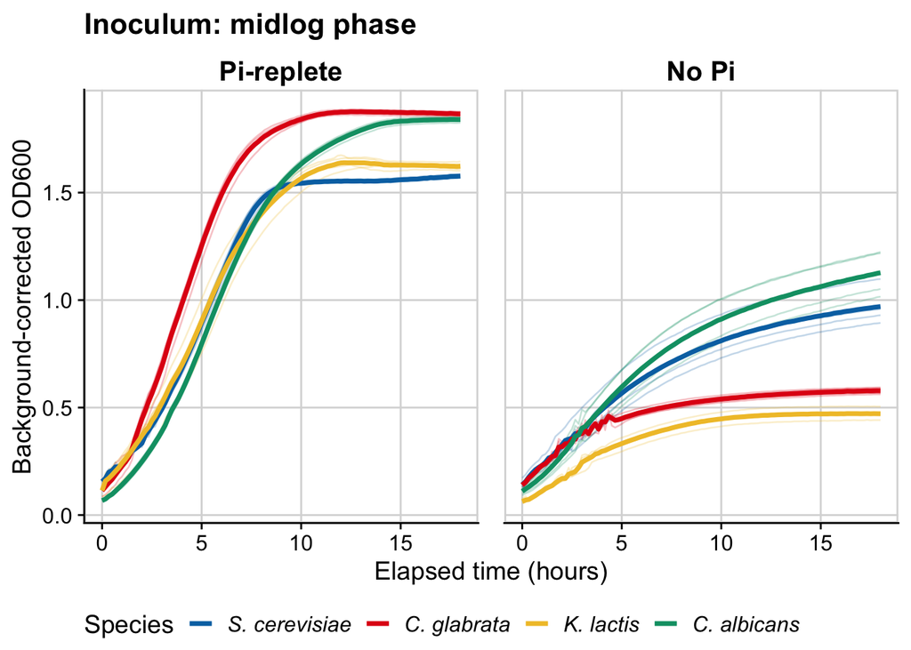

```r
growth_midlog <- plot_growth_curves("midlog")
growth_midlog
```

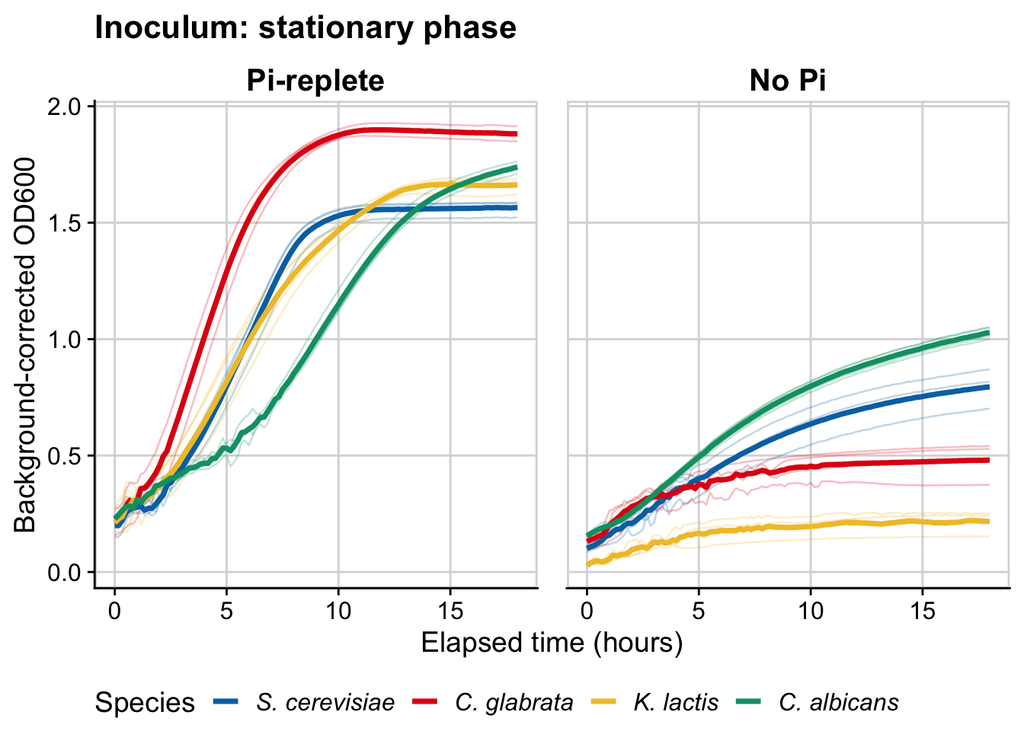

```r
growth_stationary <- plot_growth_curves("stationary")
growth_stationary
```

The reusable plotting and display-summary functions are sourced from `../script/20260727-growth-curve-helper-functions.R`. Data-shaping operations and the calculations used to obtain growth statistics remain visible below.

## Primary analysis with `growthcurver`

`growthcurver` fits a logistic model to the complete trajectory of each well. It receives the same time-matched, background-corrected OD used elsewhere, so `bg_correct = "none"` prevents double subtraction. Because the data are already in long format, `SummarizeGrowth()` is applied directly to each well. The function internally converts a failed logistic fit to zero-valued estimates with the note `"cannot fit data"`.

```r
summarize_growth_curve <- function(data) {
  fit <- SummarizeGrowth(
    data_t = data$Elapsed,
    data_n = data$Measurements,
    bg_correct = "none"
  )

  as_tibble(unclass(fit$vals))
}

growthcurver_stats <- analysis_data |>
  group_by(Date, Well, Genotype, Treatment, Inoculate) |>
  group_modify(\(.x, .y) summarize_growth_curve(.x)) |>
  ungroup() |>
  rename(
    gc_k = k,
    gc_n0 = n0,
    gc_r = r,
    gc_t_mid = t_mid,
    gc_t_gen = t_gen,
    gc_auc_e = auc_e,
    gc_auc_l = auc_l,
    gc_sigma = sigma,
    fit_note = note
  ) |>
  mutate(
    fit_ok = fit_note != "cannot fit data",
    fit_note = na_if(fit_note, "")
  )
```

The logistic growth-rate parameter `r` is the primary growth-rate estimate. Its corresponding doubling time is calculated as `log(2) / r`.

```r
growthcurver_fit_summary <- growthcurver_stats |>
  count(Inoculate, Treatment, fit_ok)

growthcurver_fit_issues <- growthcurver_stats |>
  filter(!fit_ok | !is.na(fit_note)) |>
  select(
    Date, Well, Genotype, Treatment, Inoculate,
    fit_ok, gc_sigma, fit_note
  )

growthcurver_fit_summary
```

| Inoculate | Treatment | fit_ok | n |
| --- | --- | --- | --- |
| midlog | hiPi | TRUE | 16 |
| midlog | noPi | TRUE | 16 |
| stationary | hiPi | TRUE | 16 |
| stationary | noPi | TRUE | 16 |

```r
growthcurver_fit_issues
```

| Date | Well | Genotype | Treatment | Inoculate | fit_ok | gc_sigma | fit_note |
| --- | --- | --- | --- | --- | --- | --- | --- |

### Inspect the logistic fits

Solid lines are observed curves and dashed lines are logistic fits.

```r
growthcurver_fitted <- analysis_data |>
  left_join(
    growthcurver_stats,
    by = c("Date", "Well", "Genotype", "Treatment", "Inoculate")
  ) |>
  mutate(
    fitted_OD = NAtT(k = gc_k, n0 = gc_n0, r = gc_r, t = Elapsed)
  )
```

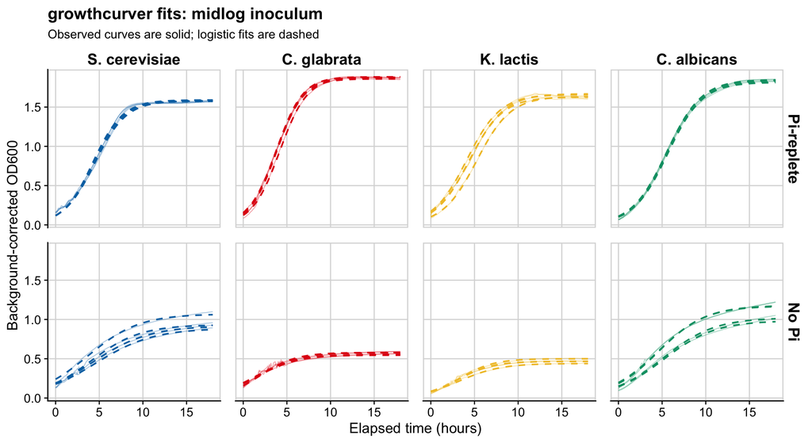

```r
growthcurver_fits_midlog <- plot_growthcurver_fits("midlog")
growthcurver_fits_midlog
```

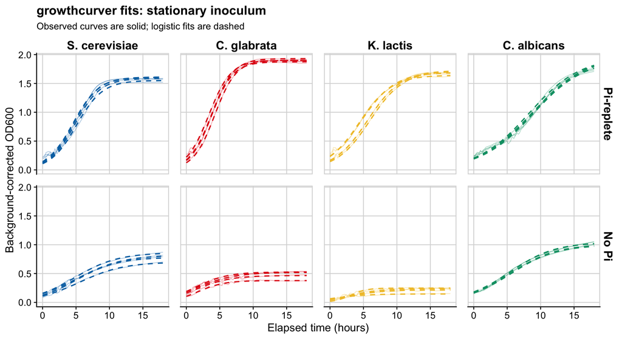

```r
growthcurver_fits_stationary <- plot_growthcurver_fits("stationary")
growthcurver_fits_stationary
```

### Compare `growthcurver` summarary stats between species

We are primarily interested in comparing the growth-rate parameter `r` and its corresponding doubling time, as well as AUC and carrying capacity `k`.

```r
growthcurver_stats_long <- growthcurver_stats |>
  pivot_longer(
    cols = c(gc_r, gc_t_gen, gc_k, gc_auc_e, gc_auc_l, gc_t_mid),
    names_to = "Metric",
    values_to = "Value"
  ) |>
  mutate(
    Metric = factor(
      Metric,
      levels = c(
        "gc_r", "gc_t_gen", "gc_k",
        "gc_auc_e", "gc_auc_l", "gc_t_mid"
      ),
      labels = c(
        "Growth Rate (r)",
        "Doubling Time",
        "Carrying Capacity (k)",
        "Empirical AUC",
        "Model AUC",
        "Time to 1/2 k"
      )
    )
  )
```

Modify the plotting scheme

```r
plot_metric_summary <- function(data, inoculum, title) {
  ggplot(
    dplyr::filter(data, Inoculate == inoculum),
    aes(x = Treatment, y = Value, group = Genotype)
  ) +
    geom_bar(
      aes(fill = Genotype),
      stat = "summary", fun = mean, position = position_dodge(0.7),
      width = 0.6
    ) +
    geom_point(
      #aes(shape = Treatment),
      color = "gray30", size = 1.5, shape = 3,
      position = position_jitterdodge(
        jitter.width = 0.10, dodge.width = 0.7
      ),
    ) +
    facet_wrap(
      ~ Metric, scales = "free_y",
    ) +
    scale_fill_manual(
      #values = c("hiPi" = "gray50", "noPi" = "salmon"),
      values = species_fill_colors, drop = FALSE
    ) +
    scale_x_discrete(labels = treatment_labels) +
    labs(
      title = paste(title, "-", inoculum, "inoculum"),
      x = NULL, y = NULL, fill = "Species"
    ) +
    theme_half_open(12) +
    theme(
      legend.text = element_text(face = 3),
      legend.position = "bottom",
      # let the legend span two rows
      legend.box = "vertical"
    )
}
```

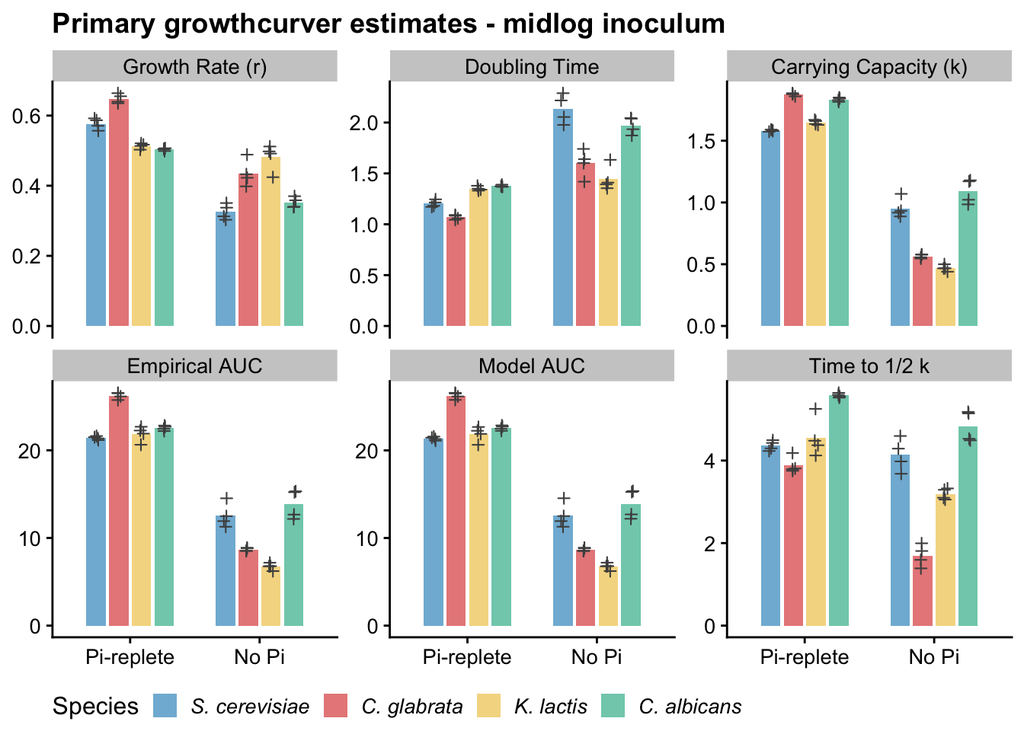

```r
growthcurver_metrics_midlog <- plot_metric_summary(
  growthcurver_stats_long, "midlog", "Primary growthcurver estimates"
)
growthcurver_metrics_midlog
```

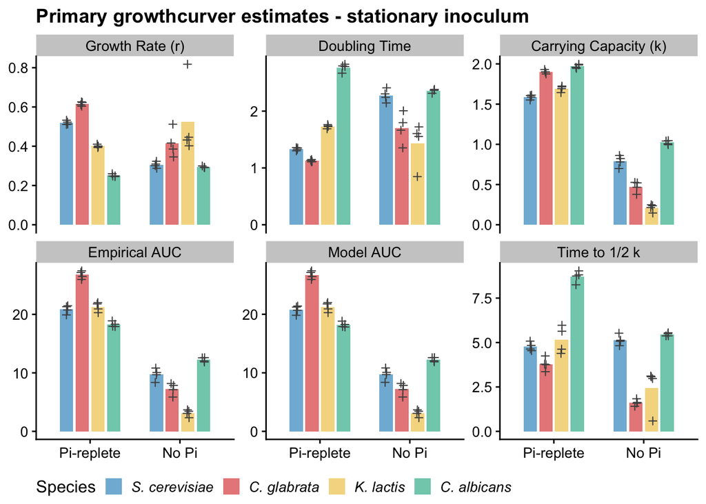

```r
growthcurver_metrics_stationary <- plot_metric_summary(
  growthcurver_stats_long, "stationary", "Primary growthcurver estimates"
)
growthcurver_metrics_stationary
```

### Quantify the response to Pi limitation

To compare species with different baseline growth characteristics, each Pi-limited well is expressed relative to the mean of the four Pi-replete wells for the same species and inoculum state. A value of zero indicates no change from the Pi-replete mean; negative and positive values indicate decreases and increases, respectively. The individual points retain the variation among the four Pi-limited replicate wells.

Growth rate and doubling time are both shown because they have complementary interpretations, although they are mathematically related. A lower growth rate corresponds to a longer doubling time, so their percentage changes are not expected to have equal magnitudes.

```r
growthcurver_replete_means <- growthcurver_stats |>
  filter(Treatment == "hiPi") |>
  group_by(Inoculate, Genotype) |>
  summarize(
    across(
      c(gc_r, gc_t_gen, gc_k, gc_auc_e, gc_t_mid),
      \(x) mean(x, na.rm = TRUE),
      .names = "{.col}_replete"
    ),
    .groups = "drop"
  )

growthcurver_pi_response <- growthcurver_stats |>
  filter(Treatment == "noPi") |>
  left_join(
    growthcurver_replete_means,
    by = c("Inoculate", "Genotype")
  ) |>
  mutate(
    growth_rate = 100 * (gc_r / gc_r_replete - 1),
    doubling_time = 100 * (gc_t_gen / gc_t_gen_replete - 1),
    carrying_capacity = 100 * (gc_k / gc_k_replete - 1),
    empirical_auc = 100 * (gc_auc_e / gc_auc_e_replete - 1),
    time_to_half_k = 100 * (gc_t_mid / gc_t_mid_replete - 1)
  )

growthcurver_pi_response_long <- growthcurver_pi_response |>
  pivot_longer(
    cols = c(
      growth_rate, doubling_time, carrying_capacity,
      empirical_auc, time_to_half_k
    ),
    names_to = "Metric",
    values_to = "Percent_change"
  ) |>
  mutate(
    Metric = factor(
      Metric,
      levels = c(
        "growth_rate", "doubling_time", "carrying_capacity",
        "empirical_auc", "time_to_half_k"
      ),
      labels = c(
        "Growth rate (r)", "Doubling time", "Carrying capacity (k)",
        "Empirical AUC", "Time to half k"
      )
    )
  )

growthcurver_pi_response_summary <- growthcurver_pi_response_long |>
  group_by(Inoculate, Genotype, Metric) |>
  summarize(
    Mean_percent_change = mean(Percent_change, na.rm = TRUE),
    .groups = "drop"
  ) |>
  pivot_wider(
    names_from = Metric,
    values_from = Mean_percent_change
  )

growthcurver_pi_response_summary
```

| Inoculate | Genotype | Growth rate (r) | Doubling time | Carrying capacity (k) | Empirical AUC | Time to half k |
| --- | --- | --- | --- | --- | --- | --- |
| midlog | S. cerevisiae | -43.48325 | 77.43884 | -39.84821 | -41.36754 | -5.189399 |
| midlog | C. glabrata | -32.82924 | 49.65391 | -69.88763 | -66.87707 | -56.314252 |
| midlog | K. lactis | -6.25583 | 7.22247 | -71.57838 | -69.19100 | -29.942494 |
| midlog | C. albicans | -30.14355 | 43.33901 | -40.61013 | -38.57878 | -13.322502 |
| stationary | S. cerevisiae | -41.27553 | 70.54621 | -50.24224 | -53.34573 | 7.624645 |
| stationary | C. glabrata | -32.65595 | 51.55680 | -75.13325 | -72.89390 | -57.353897 |
| stationary | K. lactis | 30.88336 | -17.20715 | -87.53266 | -85.28673 | -52.765567 |
| stationary | C. albicans | 17.33444 | -14.80371 | -48.14592 | -32.87309 | -37.441337 |

```r
plot_pi_response <- function(data, inoculum) {
  ggplot(
    filter(data, Inoculate == inoculum),
    aes(x = Genotype, y = Percent_change, fill = Genotype)
  ) +
    geom_hline(yintercept = 0, color = "grey45", linewidth = 0.4) +
    stat_summary(
      fun = mean, geom = "col", width = 0.65,
      color = "grey35", linewidth = 0.25
    ) +
    geom_jitter(
      width = 0.08, height = 0, shape = 21,
      color = "grey25", size = 1.8
    ) +
    facet_wrap(~Metric, ncol = 2) +
    scale_fill_manual(values = species_fill_colors, drop = FALSE) +
    scale_y_continuous(labels = \(x) paste0(x, "%")) +
    labs(
      title = paste(
        "Response to Pi limitation -", inoculum, "inoculum"
      ),
      subtitle = "Relative to the Pi-replete mean for each species",
      x = NULL,
      y = "Change from Pi-replete mean",
      fill = "Species"
    ) +
    theme(
      axis.text.x = element_text(angle = 35, hjust = 1, face = 3),
      legend.position = "none"
    )
}
```

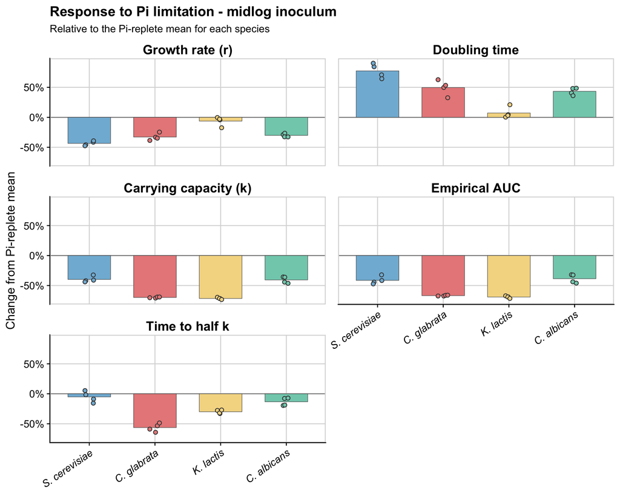

```r
plot_pi_response(growthcurver_pi_response_long, "midlog")
```

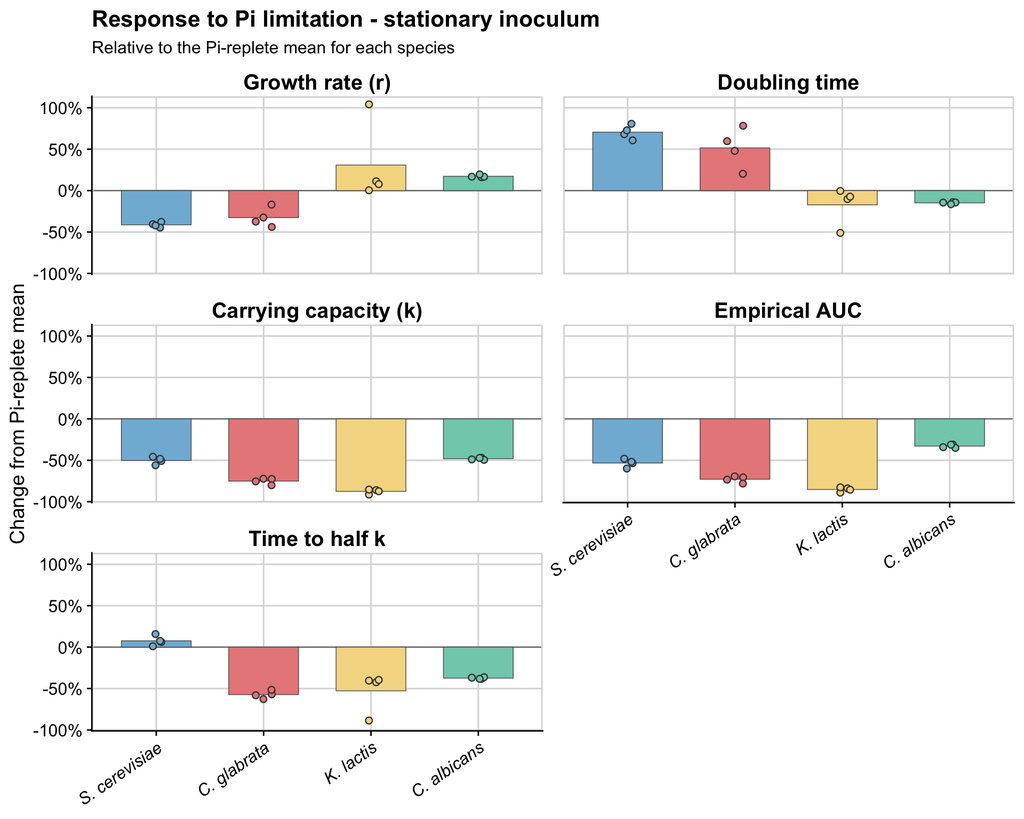

```r
plot_pi_response(growthcurver_pi_response_long, "stationary")
```

The normalized `gc_t_mid` value above asks whether Pi limitation shifts the inflection time relative to that species’ Pi-replete trajectory. The absolute Pi-limited values are also useful because they directly compare when the four species reach half of their fitted carrying capacities under the limiting condition.

```r
plot_noPi_t_mid <- function(data, inoculum) {
  ggplot(
    filter(data, Treatment == "noPi", Inoculate == inoculum),
    aes(x = Genotype, y = gc_t_mid, fill = Genotype)
  ) +
    stat_summary(
      fun = mean, geom = "col", width = 0.65,
      color = "grey35", linewidth = 0.25
    ) +
    geom_jitter(
      width = 0.08, height = 0, shape = 21,
      color = "grey25", size = 1.8
    ) +
    scale_fill_manual(values = species_fill_colors, drop = FALSE) +
    labs(
      title = paste(
        "Time to half carrying capacity under Pi limitation -",
        inoculum, "inoculum"
      ),
      x = NULL,
      y = "Time to half k (hours)",
      fill = "Species"
    ) +
    theme(
      axis.text.x = element_text(angle = 35, hjust = 1, face = 3),
      legend.position = "none"
    )
}
```

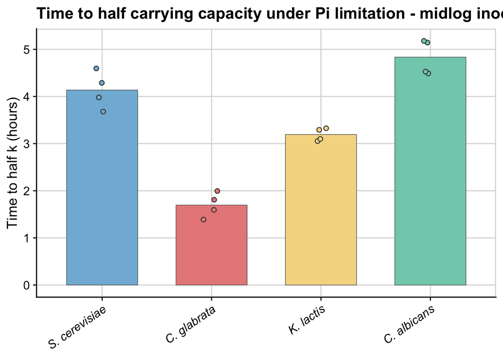

```r
plot_noPi_t_mid(growthcurver_stats, "midlog")
```

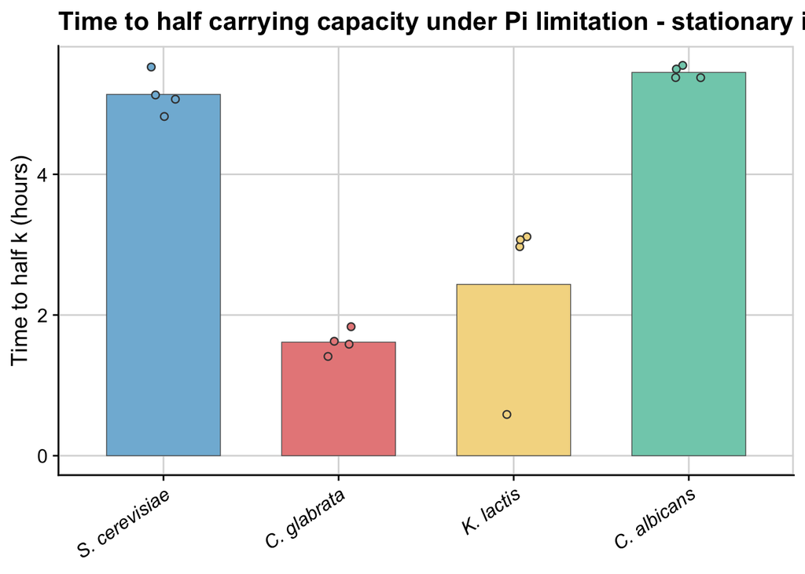

```r
plot_noPi_t_mid(growthcurver_stats, "stationary")
```

#### Interpretation

The carrying-capacity and AUC results support two broad response classes across both inoculum states. Under Pi limitation, *S. cerevisiae* and *C. albicans* retain approximately 50–60% of their Pi-replete carrying capacity and 47–67% of their Pi-replete AUC. In contrast, *C. glabrata* and *K. lactis* retain only approximately 12–30% of carrying capacity and 15–33% of AUC. Thus, the former pair continues accumulating substantially more biomass after the latter pair has reached a lower plateau.

The fitted growth rates provide more qualified support for this model. *S. cerevisiae* shows the strongest consistent slowing, with `r` decreasing by approximately 41–44%, while *C. glabrata* decreases by approximately 33%. *K. lactis* changes little with mid-log inoculum and has a higher fitted `r` with stationary inoculum. *C. albicans* decreases by approximately 30% with mid-log inoculum but also has a higher fitted `r` with stationary inoculum. Consequently, the claim that *C. albicans* generally slows its maximum growth rate is not supported across both inoculum states, even though its carrying-capacity and AUC responses consistently resemble those of *S. cerevisiae*.

Under Pi limitation, the absolute `gc_t_mid` values are later for *S. cerevisiae* and *C. albicans* (approximately 4.1–5.5 hours) than for *C. glabrata* and *K. lactis* (approximately 1.6–3.2 hours). This is consistent with the former pair reaching its higher final density over a longer portion of the experiment. Normalization adds an important caveat: `gc_t_mid` does not generally increase relative to the corresponding Pi-replete trajectory; stationary-inoculum *S. cerevisiae* is the only clear exception.

Finally, `gc_t_mid` is the time at the logistic inflection point, when the model reaches half of `k` and its absolute slope is maximal. It is not the amount of time spent at the maximum growth rate, because the mathematical maximum occurs at a single instant. Estimating a duration would require a separate definition, such as the interval during which the modeled derivative remains above 90% of its maximum. The proposed transcriptome remodeling and alternative-metabolism explanation therefore remains a mechanistic hypothesis that is consistent with parts of the growth phenotype but is not directly tested by these data.

## Secondary analysis with `gcplyr`

Lag time is not estimated because the curves do not show a clearly observed lag phase. Background has already been subtracted, so `blank = 0` prevents double subtraction. The main `gcplyr` rate uses a 13-point regression window, approximately two hours at the observed sampling interval.

### Thirteen-point derivative procedure

```r
gcplyr_deriv_13 <- analysis_data |>
  group_by(Date, Well) |>
  arrange(Elapsed, .by_group = TRUE) |>
  mutate(
    percap_rate_13 = calc_deriv(
      x = Elapsed,
      y = Measurements,
      percapita = TRUE,
      blank = 0,
      window_width_n = 13,
      trans_y = "log"
    )
  ) |>
  ungroup()

gcplyr_stats <- gcplyr_deriv_13 |>
  group_by(Date, Well, Genotype, Treatment, Inoculate) |>
  summarize(
    first_valid_rate_time = min(Elapsed[!is.na(percap_rate_13)]),
    max_growth_rate = max_gc(percap_rate_13),
    max_growth_time = Elapsed[which_max_gc(percap_rate_13)],
    doubling_time = gcplyr::doubling_time(y = max_growth_rate),
    max_at_boundary =
      abs(max_growth_time - first_valid_rate_time) < 1e-8,
    max_OD = max_gc(Measurements),
    auc = auc(
      x = Elapsed,
      y = Measurements,
      blank = 0,
      warn_negative_y = FALSE
    ),
    .groups = "drop"
  )

gcplyr_boundary_flags <- gcplyr_stats |>
  filter(max_at_boundary | is.na(max_growth_rate))

gcplyr_boundary_flags
```

| Date | Well | Genotype | Treatment | Inoculate | first_valid_rate_time | max_growth_rate | max_growth_time | doubling_time | max_at_boundary | max_OD | auc |
| --- | --- | --- | --- | --- | --- | --- | --- | --- | --- | --- | --- |
| 2026-01-03 | B3 | S. cerevisiae | hiPi | midlog | 1 | 0.3575244 | 1 | 1.9387409 | TRUE | 1.568750 | 21.161688 |
| 2026-01-03 | B5 | S. cerevisiae | hiPi | midlog | 1 | 0.3706739 | 1 | 1.8699649 | TRUE | 1.580750 | 21.356771 |
| 2026-01-03 | C3 | C. glabrata | hiPi | midlog | 1 | 0.7669625 | 1 | 0.9037563 | TRUE | 1.883750 | 25.731604 |
| 2026-01-03 | C5 | C. glabrata | hiPi | midlog | 1 | 0.5660055 | 1 | 1.2246298 | TRUE | 1.876125 | 26.493521 |
| 2026-01-03 | D2 | K. lactis | hiPi | midlog | 1 | 0.4963460 | 1 | 1.3965000 | TRUE | 1.674125 | 22.686021 |
| 2026-01-03 | D3 | K. lactis | hiPi | midlog | 1 | 0.5420016 | 1 | 1.2788656 | TRUE | 1.664625 | 22.252188 |
| 2026-01-03 | D4 | K. lactis | hiPi | midlog | 1 | 0.5027475 | 1 | 1.3787182 | TRUE | 1.628375 | 21.902438 |
| 2026-01-03 | D5 | K. lactis | hiPi | midlog | 1 | 0.5550316 | 1 | 1.2488428 | TRUE | 1.629375 | 20.631354 |
| 2026-01-03 | E2 | C. albicans | hiPi | midlog | 1 | 0.5944443 | 1 | 1.1660423 | TRUE | 1.824750 | 22.194188 |
| 2026-01-03 | E3 | C. albicans | hiPi | midlog | 1 | 0.7001378 | 1 | 0.9900154 | TRUE | 1.848750 | 22.682271 |

[output cut: 29 more lines]

Boundary maxima are retained for transparency but should be interpreted as left-boundary estimates rather than well-resolved interior maxima.

### Diagnose the 13-point rate

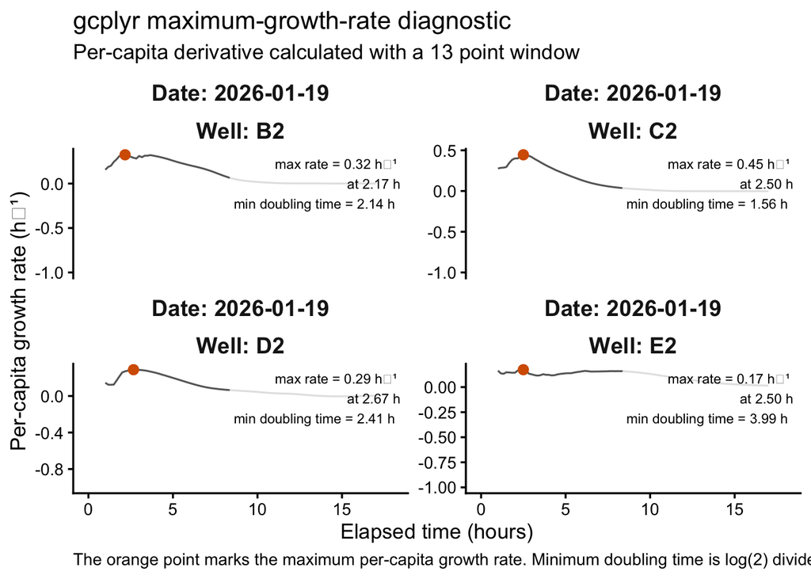

```r
max_rate_diag_13 <- plot_gcplyr_max_growth_diagnostic(
  df = analysis_data,
  date = "2026-01-19",
  wells = c("B2", "C2", "D2", "E2"),
  window_width_n = 13
)

max_rate_diag_13
```

```r
attr(max_rate_diag_13, "max_growth_summary")
```

| Date | Well | baseline_dens | max_percap | max_percap_index | max_percap_time | max_percap_dens | min_doubling_time | lag_time | tangent_intercept | lag_label | max_growth_label |
| --- | --- | --- | --- | --- | --- | --- | --- | --- | --- | --- | --- |
| 2026-01-19 | B2 | 0.22825 | 0.3237558 | 14 | 2.166667 | 0.383375 | 2.140957 | 0.5649284 | -1.660213 | lag = 0.56 h\nmax rate = 0.32 h⁻¹ | max rate = 0.32 h⁻¹\nat 2.17 h\nmin doubling time = 2.14 h |
| 2026-01-19 | C2 | 0.24325 | 0.4451424 | 16 | 2.500000 | 0.560500 | 1.557136 | 0.6247808 | -1.691782 | lag = 0.62 h\nmax rate = 0.45 h⁻¹ | max rate = 0.45 h⁻¹\nat 2.50 h\nmin doubling time = 1.56 h |
| 2026-01-19 | D2 | 0.27225 | 0.2879981 | 17 | 2.666667 | 0.509625 | 2.406777 | 0.4897269 | -1.442075 | lag = 0.49 h\nmax rate = 0.29 h⁻¹ | max rate = 0.29 h⁻¹\nat 2.67 h\nmin doubling time = 2.41 h |
| 2026-01-19 | E2 | 0.22925 | 0.1738961 | 16 | 2.500000 | 0.403500 | 3.985984 | -0.7511556 | -1.342319 | lag = -0.75 h\nmax rate = 0.17 h⁻¹ | max rate = 0.17 h⁻¹\nat 2.50 h\nmin doubling time = 3.99 h |

```r
gcplyr_stats_long <- gcplyr_stats |>
  pivot_longer(
    cols = c(max_growth_rate, doubling_time, max_OD, auc),
    names_to = "Metric",
    values_to = "Value"
  ) |>
  mutate(
    Metric = factor(
      Metric,
      levels = c("max_growth_rate", "doubling_time", "max_OD", "auc"),
      labels = c(
        "Maximum observed growth rate",
        "Doubling time",
        "Maximum OD",
        "AUC"
      )
    )
  )
```

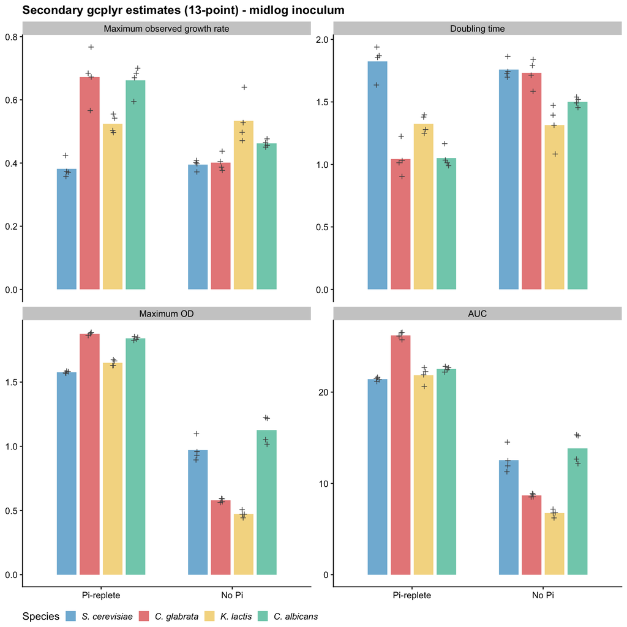

```r
gcplyr_metrics_midlog <- plot_metric_summary(
  gcplyr_stats_long, "midlog", "Secondary gcplyr estimates (13-point)"
)
gcplyr_metrics_midlog
```

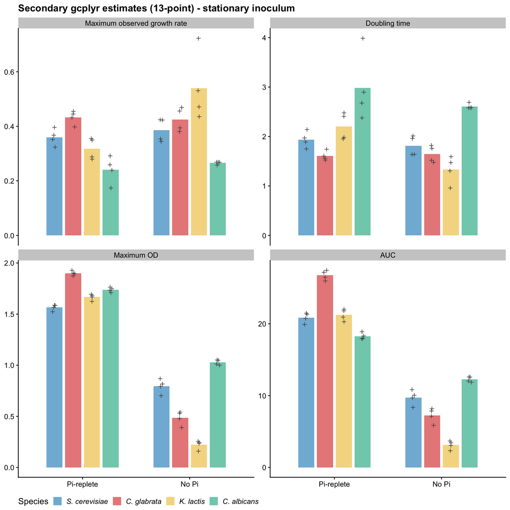

```r
gcplyr_metrics_stationary <- plot_metric_summary(
  gcplyr_stats_long, "stationary", "Secondary gcplyr estimates (13-point)"
)
gcplyr_metrics_stationary
```

### Sensitivity analysis: drop two + LOESS 0.10 + 9-point derivative

The first two observations are removed within each curve before smoothing. Elapsed time is left on its original scale. Degree-1 LOESS with `span = 0.10` is followed by a 9-point per-capita derivative.

```r
gcplyr_loess_data <- analysis_data |>
  group_by(Date, Well, Genotype, Treatment, Inoculate) |>
  arrange(Elapsed, .by_group = TRUE) |>
  filter(row_number() > 2) |>
  mutate(
    OD_loess = smooth_data(
      x = Elapsed,
      y = Measurements,
      sm_method = "loess",
      span = 0.10,
      degree = 1,
      control = loess.control(surface = "direct")
    ),
    percap_rate_loess = calc_deriv(
      x = Elapsed,
      y = OD_loess,
      percapita = TRUE,
      blank = 0,
      window_width_n = 9,
      trans_y = "log"
    )
  ) |>
  ungroup()

gcplyr_loess_stats <- gcplyr_loess_data |>
  group_by(Date, Well, Genotype, Treatment, Inoculate) |>
  summarize(
    first_valid_rate_time = min(Elapsed[!is.na(percap_rate_loess)]),
    max_growth_rate = max_gc(percap_rate_loess),
    max_growth_time = Elapsed[which_max_gc(percap_rate_loess)],
    doubling_time = gcplyr::doubling_time(y = max_growth_rate),
    max_at_boundary =
      abs(max_growth_time - first_valid_rate_time) < 1e-8,
    .groups = "drop"
  )
```

The sensitivity table and plots compare both model-free rate procedures.

```r
gcplyr_sensitivity <- gcplyr_stats |>
  select(
    Date, Well, Genotype, Treatment, Inoculate,
    rate_13 = max_growth_rate,
    doubling_13 = doubling_time,
    boundary_13 = max_at_boundary
  ) |>
  left_join(
    gcplyr_loess_stats |>
      select(
        Date, Well,
        rate_loess = max_growth_rate,
        doubling_loess = doubling_time,
        boundary_loess = max_at_boundary
      ),
    by = c("Date", "Well")
  )

gcplyr_sensitivity_summary <- gcplyr_sensitivity |>
  summarize(
    rate_correlation = cor(rate_13, rate_loess, use = "complete.obs"),
    median_absolute_rate_difference =
      median(abs(rate_13 - rate_loess), na.rm = TRUE),
    boundary_estimates_13 = sum(boundary_13, na.rm = TRUE),
    boundary_estimates_loess = sum(boundary_loess, na.rm = TRUE)
  )

gcplyr_sensitivity_summary
```

| rate_correlation | median_absolute_rate_difference | boundary_estimates_13 | boundary_estimates_loess |
| --- | --- | --- | --- |
| 0.9766349 | 0.01601919 | 39 | 39 |

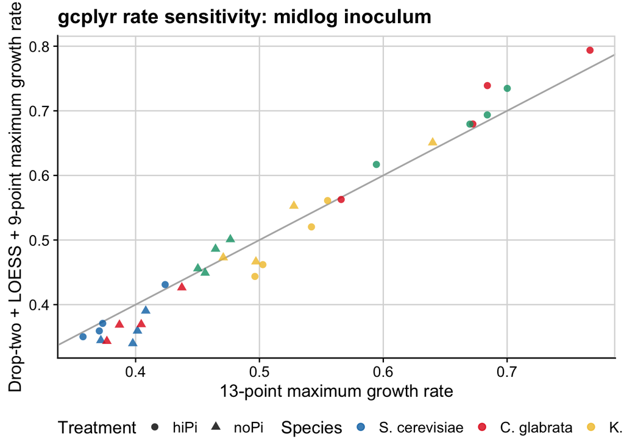

```r
plot_gcplyr_sensitivity("midlog")
```

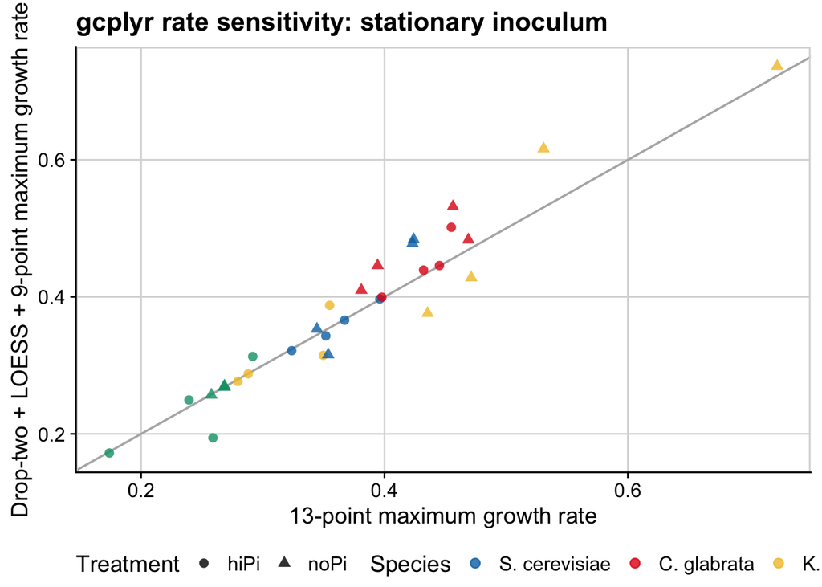

```r
plot_gcplyr_sensitivity("stationary")
```

## Compare primary and secondary estimates

The packages estimate related but non-identical quantities. `growthcurver` estimates logistic `r` and carrying capacity, whereas `gcplyr` uses the largest observed 13-point per-capita slope and maximum observed OD.

```r
method_comparison <- gcplyr_stats |>
  left_join(
    growthcurver_stats,
    by = c("Date", "Well", "Genotype", "Treatment", "Inoculate")
  )

method_comparison_long <- bind_rows(
  method_comparison |>
    transmute(
      Date, Well, Genotype, Treatment, Inoculate,
      Metric = "Growth rate",
      gcplyr = max_growth_rate,
      growthcurver = gc_r
    ),
  method_comparison |>
    transmute(
      Date, Well, Genotype, Treatment, Inoculate,
      Metric = "Doubling time",
      gcplyr = doubling_time,
      growthcurver = gc_t_gen
    ),
  method_comparison |>
    transmute(
      Date, Well, Genotype, Treatment, Inoculate,
      Metric = "Maximum OD / carrying capacity",
      gcplyr = max_OD,
      growthcurver = gc_k
    ),
  method_comparison |>
    transmute(
      Date, Well, Genotype, Treatment, Inoculate,
      Metric = "Empirical AUC",
      gcplyr = auc,
      growthcurver = gc_auc_e
    )
) |>
  mutate(
    Metric = factor(
      Metric,
      levels = c(
        "Growth rate",
        "Doubling time",
        "Maximum OD / carrying capacity",
        "Empirical AUC"
      )
    )
  )

auc_agreement <- method_comparison |>
  summarize(
    max_absolute_difference = max(abs(auc - gc_auc_e), na.rm = TRUE),
    mean_absolute_difference = mean(abs(auc - gc_auc_e), na.rm = TRUE)
  )

auc_agreement
```

| max_absolute_difference | mean_absolute_difference |
| --- | --- |
| 0 | 0 |

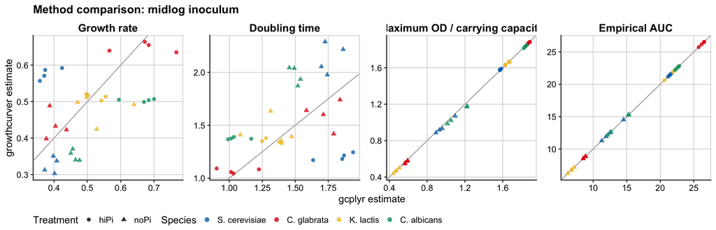

```r
method_comparison_midlog <- plot_method_comparison("midlog")
method_comparison_midlog
```

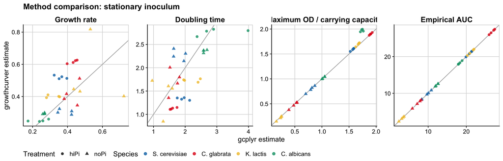

```r
method_comparison_stationary <- plot_method_comparison("stationary")
method_comparison_stationary
```